# Introduction

The New York Times has published their COVID-19 tracking data on [GitHub](https://github.com/nytimes/covid-19-data). The data is simple and tidy and the county-level data includes the FIPS (Federal Information Processing Standards) code for each.

Using FIPS as the common reference point, I attempted to marry COVID-19 infection rates with county median income and population information.

This is the result.

# COVID-19 Infection Data

```python
import numpy as np
import pandas as pd
import matplotlib.pyplot as plt
import requests
import datetime as dt
%matplotlib inline
```

```python
# COVID data source from NYT: https://github.com/nytimes/covid-19-data
url = 'https://raw.githubusercontent.com/nytimes/covid-19-data/master/us-counties.csv'
r = requests.get(url, allow_redirects=True)
open('us_county_covid.csv', 'wb').write(r.content)
```

```
12276695
```

```python
# Create Dataframe from COVID dataset
# Keep the FIPS codes as string

covid_df = pd.read_csv('us_county_covid.csv', dtype={'fips':str}, parse_dates=['date'])
covid_df.describe
```

```
<bound method NDFrame.describe of              date      county       state   fips  cases  deaths
0      2020-01-21   Snohomish  Washington  53061      1       0
1      2020-01-22   Snohomish  Washington  53061      1       0
2      2020-01-23   Snohomish  Washington  53061      1       0
3      2020-01-24        Cook    Illinois  17031      1       0
4      2020-01-24   Snohomish  Washington  53061      1       0
...           ...         ...         ...    ...    ...     ...
310251 2020-07-08  Sweetwater     Wyoming  56037    124       0
310252 2020-07-08       Teton     Wyoming  56039    149       1
310253 2020-07-08       Uinta     Wyoming  56041    192       0
310254 2020-07-08    Washakie     Wyoming  56043     42       5
310255 2020-07-08      Weston     Wyoming  56045      1       0

[310256 rows x 6 columns]>
```

## Geographic Exceptions

This dataset has some geographic exceptions, noted [here](https://github.com/nytimes/covid-19-data#geographic-exceptions), including:

- Joplin, MO
- Kansas City, MO
- New York city

County FIPS are not assigned to these locations, so I will assign a fake FIPS code for each to use when comparing to income and population data.

### Fake FIPS Codes

- NYC: 100001
- KC, MO: 100002
- Joplin, MO: 100003

```python
covid_df.loc[(covid_df.county == 'New York City') & (covid_df.state == 'New York'), 'fips'] = '100001'
covid_df.loc[(covid_df.county == 'Kansas City') & (covid_df.state == 'Missouri'), 'fips'] = '100002'
covid_df.loc[(covid_df.county == 'Joplin') & (covid_df.state == 'Missouri'), 'fips'] = '100003'
```

The dataset also contains cases where the county is "unknown." We cannot use those cases in this analysis, so anything else that does not have a FIPS code should be dropped.

```python
covid_df = covid_df.dropna(subset=['fips'])
```

# Income Data

Next: need a source for median income data per county with FIPS codes. Source: [USDA Economic Research Service](https://www.ers.usda.gov/data-products/county-level-data-sets/download-data/)

```python
# Download Excel file with median county income
url = 'https://www.ers.usda.gov/webdocs/DataFiles/48747/Unemployment.xls?v=1887.2'
r = requests.get(url, allow_redirects=True)
open('us_county_income.xls', 'wb').write(r.content)
```

```
2322944
```

```python
# Import income dataset
temp_income_df = pd.read_excel (r'us_county_income.xls', sheet_name='Unemployment Med HH Income')
temp_income_df.dtypes
```

```
Unemployment and median household income for the U.S., States, and counties, 2000-19    object
Unnamed: 1                                                                              object
Unnamed: 2                                                                              object
Unnamed: 3                                                                              object
Unnamed: 4                                                                              object
                                                                                         ...
Unnamed: 83                                                                             object
Unnamed: 84                                                                             object
Unnamed: 85                                                                             object
Unnamed: 86                                                                             object
Unnamed: 87                                                                             object
Length: 88, dtype: object
```

```python
# The Excel file has lots of historical data that we don't need, so we will only pull in the columns needed for FIPS and median income
# Also, skip the first 7 rows because this is a horribly formatted document
income_df = temp_income_df.iloc[ 7: , [0,2,3,86]]
income_df.columns = ['fips', 'county', 'rural_urban_code', 'median_income']
income_df
```

|  | fips | county | rural_urban_code | median_income |
| --- | --- | --- | --- | --- |
| 7 | 00000 | United States | NaN | 61937 |
| 8 | 01000 | Alabama | NaN | 49881 |
| 9 | 01001 | Autauga County, AL | 2 | 59338 |
| 10 | 01003 | Baldwin County, AL | 3 | 57588 |
| 11 | 01005 | Barbour County, AL | 6 | 34382 |
| ... | ... | ... | ... | ... |
| 3277 | 72145 | Vega Baja Municipio, PR | 1 | NaN |
| 3278 | 72147 | Vieques Municipio, PR | 7 | NaN |
| 3279 | 72149 | Villalba Municipio, PR | 2 | NaN |
| 3280 | 72151 | Yabucoa Municipio, PR | 1 | NaN |
| 3281 | 72153 | Yauco Municipio, PR | 2 | NaN |

3275 rows × 4 columns

```python
# The COVID dataset doesn't break down Puerto Rico by county and the income dataset doesn't have median income for the regions of PR, so we'll drop PR from the income dataset
# (Sorry Puerto Rico ❤️🇵🇷)
income_df = income_df.dropna(subset=['median_income'])

# We also only want counties - not states, so we can drop anything whose rural_urban_code is NaN
# Then we can drop that column entirely
income_df = income_df.dropna(subset=['rural_urban_code'])
income_df = income_df.drop(columns=['rural_urban_code'])
income_df
```

|  | fips | county | median_income |
| --- | --- | --- | --- |
| 9 | 01001 | Autauga County, AL | 59338 |
| 10 | 01003 | Baldwin County, AL | 57588 |
| 11 | 01005 | Barbour County, AL | 34382 |
| 12 | 01007 | Bibb County, AL | 46064 |
| 13 | 01009 | Blount County, AL | 50412 |
| ... | ... | ... | ... |
| 3198 | 56037 | Sweetwater County, WY | 73315 |
| 3199 | 56039 | Teton County, WY | 99087 |
| 3200 | 56041 | Uinta County, WY | 63401 |
| 3201 | 56043 | Washakie County, WY | 55190 |
| 3202 | 56045 | Weston County, WY | 54319 |

3141 rows × 3 columns

```python
# Finally, we need to add in the median incomes for our three fake FIPS codes
# This data comes from the US Census Bureau
# https://www.census.gov/quickfacts/fact/table/newyorkcitynewyork,kansascitycitymissouri,joplincitymissouri/AGE295219

d = {'fips': ['100001', '100002', '100003'],
     'county': ['New York City, NY', 'Kansas City, MO', 'Joplin, MO'],
     'median_income': [60762, 52405, 42782]}
extra_cities = pd.DataFrame(data=d)
income_df = income_df.append(extra_cities, ignore_index=True)
income_df
```

|  | fips | county | median_income |
| --- | --- | --- | --- |
| 0 | 01001 | Autauga County, AL | 59338 |
| 1 | 01003 | Baldwin County, AL | 57588 |
| 2 | 01005 | Barbour County, AL | 34382 |
| 3 | 01007 | Bibb County, AL | 46064 |
| 4 | 01009 | Blount County, AL | 50412 |
| ... | ... | ... | ... |
| 3139 | 56043 | Washakie County, WY | 55190 |
| 3140 | 56045 | Weston County, WY | 54319 |
| 3141 | 100001 | New York City, NY | 60762 |
| 3142 | 100002 | Kansas City, MO | 52405 |
| 3143 | 100003 | Joplin, MO | 42782 |

3144 rows × 3 columns

# Population Data

Then, need a source for population data per county with FIPS codes. Source: [USDA Economic Research Service](https://www.ers.usda.gov/data-products/county-level-data-sets/download-data/)

```python
# Download Excel file with county population
url = 'https://www.ers.usda.gov/webdocs/DataFiles/48747/PopulationEstimates.xls?v=1887.2'
r = requests.get(url, allow_redirects=True)
open('us_population.xls', 'wb').write(r.content)
```

```
5619712
```

```python
# Import population dataset
temp_pop_df = pd.read_excel (r'us_population.xls', sheet_name='Population Estimates 2010-19')
temp_pop_df.dtypes
```

```
Population estimates for the U.S., States, and counties, 2010-19 (see the second tab in this workbook for variable name descriptions)    object
Unnamed: 1                                                                                                                               object
Unnamed: 2                                                                                                                               object
Unnamed: 3                                                                                                                               object
Unnamed: 4                                                                                                                               object
                                                                                                                                          ...
Unnamed: 160                                                                                                                             object
Unnamed: 161                                                                                                                             object
Unnamed: 162                                                                                                                             object
Unnamed: 163                                                                                                                             object
Unnamed: 164                                                                                                                             object
Length: 165, dtype: object
```

```python
# This Excel file also has lots of historical data that we don't need, so we will only pull in the columns needed for FIPS and median income
# Also, skip the first 2 rows because this is a horribly formatted document
# And cut Puerto Rico out from the end of the file (sorry again)
pop_df = temp_pop_df.iloc[ 2:3196 , [0,2,3,19]]
pop_df.columns = ['fips', 'county', 'rural_urban_code', 'population_2019']
pop_df
```

|  | fips | county | rural_urban_code | population_2019 |
| --- | --- | --- | --- | --- |
| 2 | 00000 | United States | NaN | 328239523 |
| 3 | 01000 | Alabama | NaN | 4903185 |
| 4 | 01001 | Autauga County | 2 | 55869 |
| 5 | 01003 | Baldwin County | 4 | 223234 |
| 6 | 01005 | Barbour County | 6 | 24686 |
| ... | ... | ... | ... | ... |
| 3191 | 56037 | Sweetwater County | 5 | 42343 |
| 3192 | 56039 | Teton County | 7 | 23464 |
| 3193 | 56041 | Uinta County | 7 | 20226 |
| 3194 | 56043 | Washakie County | 7 | 7805 |
| 3195 | 56045 | Weston County | 7 | 6927 |

3194 rows × 4 columns

```python
# We also only want counties - not states, so we can drop anything whose rural_urban_code is NaN
# Then we can drop that column entirely
pop_df = pop_df.dropna(subset=['rural_urban_code'])
pop_df = pop_df.drop(columns=['rural_urban_code'])
pop_df
```

|  | fips | county | population_2019 |
| --- | --- | --- | --- |
| 4 | 01001 | Autauga County | 55869 |
| 5 | 01003 | Baldwin County | 223234 |
| 6 | 01005 | Barbour County | 24686 |
| 7 | 01007 | Bibb County | 22394 |
| 8 | 01009 | Blount County | 57826 |
| ... | ... | ... | ... |
| 3191 | 56037 | Sweetwater County | 42343 |
| 3192 | 56039 | Teton County | 23464 |
| 3193 | 56041 | Uinta County | 20226 |
| 3194 | 56043 | Washakie County | 7805 |
| 3195 | 56045 | Weston County | 6927 |

3137 rows × 3 columns

```python
# Finally, we need to add in the populations for our three fake FIPS codes
# This data comes from the US Census Bureau
# https://www.census.gov/quickfacts/fact/table/newyorkcitynewyork,kansascitycitymissouri,joplincitymissouri/AGE295219

d = {'fips': ['100001', '100002', '100003'],
     'county': ['New York City, NY', 'Kansas City, MO', 'Joplin, MO'],
     'population_2019': [8336817, 495327, 50925]}
extra_cities = pd.DataFrame(data=d)
pop_df = pop_df.append(extra_cities, ignore_index=True)
pop_df
```

|  | fips | county | population_2019 |
| --- | --- | --- | --- |
| 0 | 01001 | Autauga County | 55869 |
| 1 | 01003 | Baldwin County | 223234 |
| 2 | 01005 | Barbour County | 24686 |
| 3 | 01007 | Bibb County | 22394 |
| 4 | 01009 | Blount County | 57826 |
| ... | ... | ... | ... |
| 3135 | 56043 | Washakie County | 7805 |
| 3136 | 56045 | Weston County | 6927 |
| 3137 | 100001 | New York City, NY | 8336817 |
| 3138 | 100002 | Kansas City, MO | 495327 |
| 3139 | 100003 | Joplin, MO | 50925 |

3140 rows × 3 columns

# Merging the Datasets

Now that the three datasets have been cleaned up, it's time to merge them together into one giant dataset

```python
# Merge income and population dataframes together based on FIPS
income_pop_df = pd.merge(income_df, pop_df[['fips', 'population_2019']], on='fips')
income_pop_df
```

|  | fips | county | median_income | population_2019 |
| --- | --- | --- | --- | --- |
| 0 | 01001 | Autauga County, AL | 59338 | 55869 |
| 1 | 01003 | Baldwin County, AL | 57588 | 223234 |
| 2 | 01005 | Barbour County, AL | 34382 | 24686 |
| 3 | 01007 | Bibb County, AL | 46064 | 22394 |
| 4 | 01009 | Blount County, AL | 50412 | 57826 |
| ... | ... | ... | ... | ... |
| 3134 | 56043 | Washakie County, WY | 55190 | 7805 |
| 3135 | 56045 | Weston County, WY | 54319 | 6927 |
| 3136 | 100001 | New York City, NY | 60762 | 8336817 |
| 3137 | 100002 | Kansas City, MO | 52405 | 495327 |
| 3138 | 100003 | Joplin, MO | 42782 | 50925 |

3139 rows × 4 columns

```python
# Now merge all three together
combined_df = pd.merge(covid_df, income_pop_df[['fips', 'median_income', 'population_2019']], on='fips')
#combined_df.to_csv('combined.csv')
combined_df.dtypes
```

```
date               datetime64[ns]
county                     object
state                      object
fips                       object
cases                       int64
deaths                      int64
median_income              object
population_2019            object
dtype: object
```

```python
# Test with a DF for just one county
snohomish_df = combined_df[combined_df['fips']=='53061']
snohomish_df.info()
```

```
<class 'pandas.core.frame.DataFrame'>
Int64Index: 170 entries, 0 to 169
Data columns (total 8 columns):
 #   Column           Non-Null Count  Dtype
---  ------           --------------  -----
 0   date             170 non-null    datetime64[ns]
 1   county           170 non-null    object
 2   state            170 non-null    object
 3   fips             170 non-null    object
 4   cases            170 non-null    int64
 5   deaths           170 non-null    int64
 6   median_income    170 non-null    object
 7   population_2019  170 non-null    object
dtypes: datetime64[ns](1), int64(2), object(5)
memory usage: 12.0+ KB
```

# Plotting Data

With a combined dataframe, we can try to plot some data

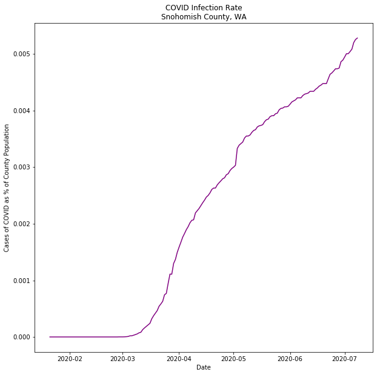

```python
# Test a plot
# Create figure and plot space
fig, ax = plt.subplots(figsize=(10, 10))

# Add x-axis and y-axis
ax.plot(snohomish_df['date'],
        snohomish_df['cases']/snohomish_df['population_2019'],
        color='purple')

# Set title and labels for axes
ax.set(xlabel="Date",
       ylabel="Cases of COVID as % of County Population",
       title="COVID Infection Rate\nSnohomish County, WA")

plt.show()
```

# Results by Income

Now that we have a dataset with COVID, income, and population data married together we can start to explore a bit.

For reference, the median [US Census Bureau](https://bit.ly/320ptAZ) reports the median household income in 2018 was **\$61,937**. In the dataset provided here, the county with the lowest median income is Wilcox County, AL (\$25,385) and the county with the highest median income is Loudoun County, VA (\\$140,382)

```python
# Figure out populations of upper income and lower income counties
upper_pop = income_pop_df[income_pop_df['median_income']>61937]['population_2019'].sum()
lower_pop = income_pop_df[income_pop_df['median_income']<=61937]['population_2019'].sum()
print(f'{upper_pop} people live in counties where the median income is higher than the US median.')
print(f'{lower_pop} people live in counties where the median income is lower than the US median.')
```

```
161875067 people live in counties where the median income is higher than the US median.
175232137 people live in counties where the median income is lower than the US median.
```

```python
# Create a method that accepts an upper and lower salary range and calculates cases for that population

# Set a date range from the start of data collection to yesterday
daterange = pd.date_range(dt.date(2020,1,12), (dt.date.today() - dt.timedelta(days=1)))

def cases_by_income(min,max):

    target_df = combined_df[combined_df.median_income>min]
    target_df = target_df[target_df.median_income<=max]

    cases_income_df = pd.DataFrame([], columns=['date', 'cases', '14-day', '28-day', 'population'])

    # Calculate population for this group
    group_population = income_pop_df[(income_pop_df.median_income>min)&(income_pop_df.median_income<=max)]['population_2019'].sum()

    for single_date in daterange:
        cases_for_date = target_df[(target_df['date'] >= single_date) & ((target_df['date'] < single_date+dt.timedelta(days=1)))]['cases'].sum()

        cases_14_ago = target_df[(target_df['date'] >= single_date+dt.timedelta(days=-15)) & ((target_df['date'] < single_date+dt.timedelta(days=-14)))]['cases'].sum()
        cases_28_ago = target_df[(target_df['date'] >= single_date+dt.timedelta(days=-29)) & ((target_df['date'] < single_date+dt.timedelta(days=-28)))]['cases'].sum()

        daily = {'date' : single_date, 'cases' : cases_for_date, '14-day' : cases_for_date-cases_14_ago, '28-day' : cases_for_date-cases_28_ago, 'population' : group_population}
        cases_income_df = cases_income_df.append(daily, ignore_index=True)

    return cases_income_df
```

```python
# Create a method that accepts an upper and lower population and calculates cases for that population

# Set a date range from the start of data collection to yesterday
daterange = pd.date_range(dt.date(2020,1,12), (dt.date.today() - dt.timedelta(days=1)))

def cases_by_population(min,max):

    target_df = combined_df[combined_df.population_2019>min]
    target_df = target_df[target_df.population_2019<=max]

    cases_population_df = pd.DataFrame([], columns=['date', 'cases', '14-day', '28-day', 'population'])

    # Calculate population for this group
    group_population = income_pop_df[(income_pop_df.population_2019>min)&(income_pop_df.population_2019<=max)]['population_2019'].sum()

    for single_date in daterange:
        cases_for_date = target_df[(target_df['date'] >= single_date) & ((target_df['date'] < single_date+dt.timedelta(days=1)))]['cases'].sum()

        cases_14_ago = target_df[(target_df['date'] >= single_date+dt.timedelta(days=-15)) & ((target_df['date'] < single_date+dt.timedelta(days=-14)))]['cases'].sum()
        cases_28_ago = target_df[(target_df['date'] >= single_date+dt.timedelta(days=-29)) & ((target_df['date'] < single_date+dt.timedelta(days=-28)))]['cases'].sum()

        daily = {'date' : single_date, 'cases' : cases_for_date, '14-day' : cases_for_date-cases_14_ago, '28-day' : cases_for_date-cases_28_ago, 'population' : group_population}
        cases_population_df = cases_population_df.append(daily, ignore_index=True)

    return cases_population_df
```

```python
# Create a method that plots the change in cases/population for a series of salary ranges
# Inputs are
# - an array of ranges [low, high]
# - either 14 or 28 for the trailing average
# - 'i' for income or 'p' for population

def plot_by_ranges(ranges, trail_days, metric):
    # Create figure and plot space
    fig, ax = plt.subplots(figsize=(20, 10))

    for range in ranges:

        if metric == 'i':
            range_label = "\$" + "${:,.0f}".format(range[0]) + " - \$" + "${:,.0f}".format(range[1])
            title_metric = 'Median Income'
            range_df = cases_by_income(range[0],range[1])
        else:
            range_label = "${:,.0f}".format(range[0]) + " - " + "${:,.0f}".format(range[1])
            title_metric = 'County Population'
            range_df = cases_by_population(range[0],range[1])


        if trail_days == 14:
            ax.plot(range_df['date'],
                    (range_df['14-day']/range_df['population'])*100,
                    label=range_label)
            title_days = "14"
        else:
            ax.plot(range_df['date'],
                    (range_df['28-day']/range_df['population'])*100,
                    label=range_label)
            title_days = "28"

    # Set title and labels for axes
    ax.set(xlabel="Date",
           ylabel="Cases of COVID as % of Population",
           title= "Trailing " + title_days + " Days COVID Growth Rate by " + title_metric)

    plt.axvline(dt.datetime(2020, 5, 25), linestyle="-.", color="gray")
    plt.text(dt.datetime(2020, 5, 27),0,'Memorial Day',rotation=90)

    plt.axvline(dt.datetime(2020, 6, 8), linestyle="-.", color="gray")
    plt.text(dt.datetime(2020, 6, 9),0,'Memorial Day+14',rotation=90)

    plt.axvline(dt.datetime(2020, 7, 4), linestyle="-.", color="gray")
    plt.text(dt.datetime(2020, 7, 6),0,'July 4th',rotation=90)

    plt.legend(loc="upper left")
    plt.show()
```

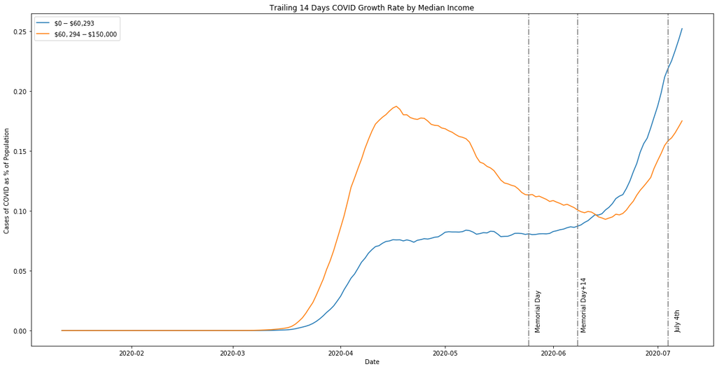

```python
# Divide the country into upper/lower income halves
plot_by_ranges([[0,60293],[60294,150000]],14,'i')
```

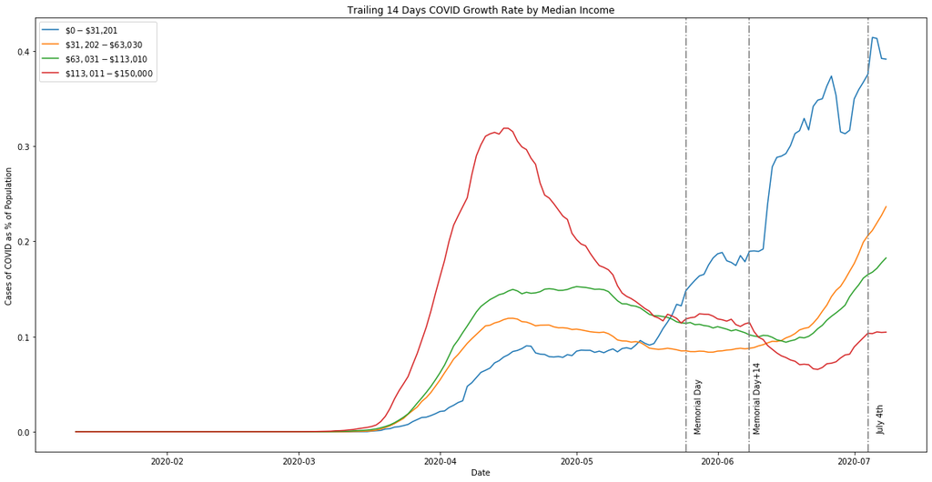

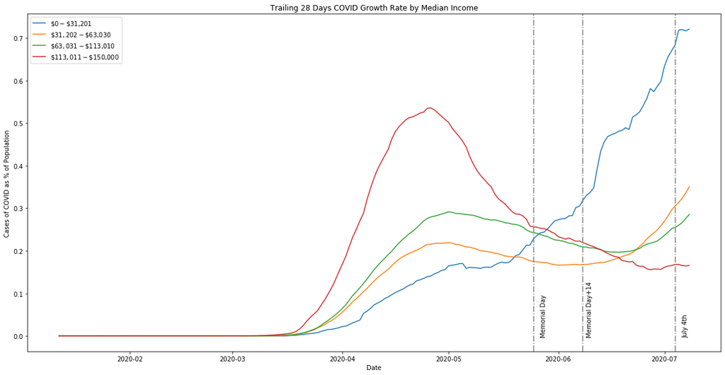

```python
# Divide the country into quartiles
plot_by_ranges([[0,31201],[31202,63030],[63031,113010],[113011,150000]],14,'i')
plot_by_ranges([[0,31201],[31202,63030],[63031,113010],[113011,150000]],28,'i')
```

# Results by Population

And although this started as an exercise to examine the differences in income level, we can do the same type of analysis based on the population of the counties.

For reference, the median county population in our dataset is 25,925. The least populated county is Kalawao County, HI (86) and the most populated county is Los Angeles County, CA (10,039,107).

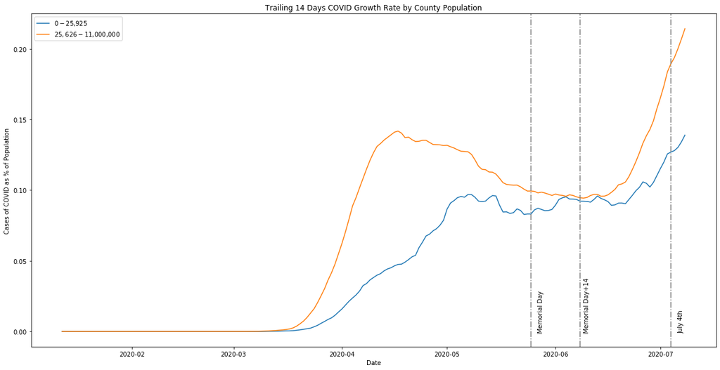

```python
# Divide the country into upper/lower population halves
plot_by_ranges([[0,25925],[25626,11000000]],14,'p')
```

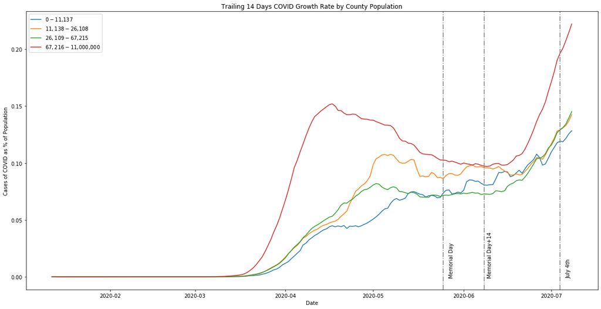

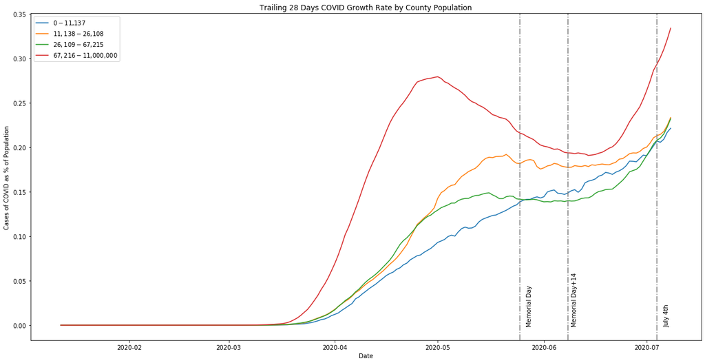

```python
# Divide the country into population quartilesishes
plot_by_ranges([[0,11137],[11138,26108],[26109,67215],[67216,11000000]],14,'p')
plot_by_ranges([[0,11137],[11138,26108],[26109,67215],[67216,11000000]],28,'p')
```